# Predicting Fire Suppression Calls

Author

Angela Zhao

Published

October 2, 2024

# Introduction

# Data Preparation

The data comes from the Baltimore County firehouse and includes data starting from 2015. Importantly, we extract the hour of the call from the time column of the Excel.

## Data Exploration

Please take a look at the different tabs of the exploratory analysis. In this brief exploratory analysis, we see that the “Call Count by Day and Month” tab shows that there are not large distinctions across months of the year or across days of the week. Likewise, there are not large distinctions in the number of calls between holidays v.s. non-holidays and weekends v.s. weekdays. The heatmap suggests that the temporal patterns of the number of calls is relatively similar across all days of the week.

Next, we explore whether holidays impact the number of calls. The “Holiday v.s. Non-Holiday” tab shows the counts on holidays and non-holidays, as well as the average number of calls per day on each. It does not seem like holidays have a large impact.

**Call Count by Day and Month**

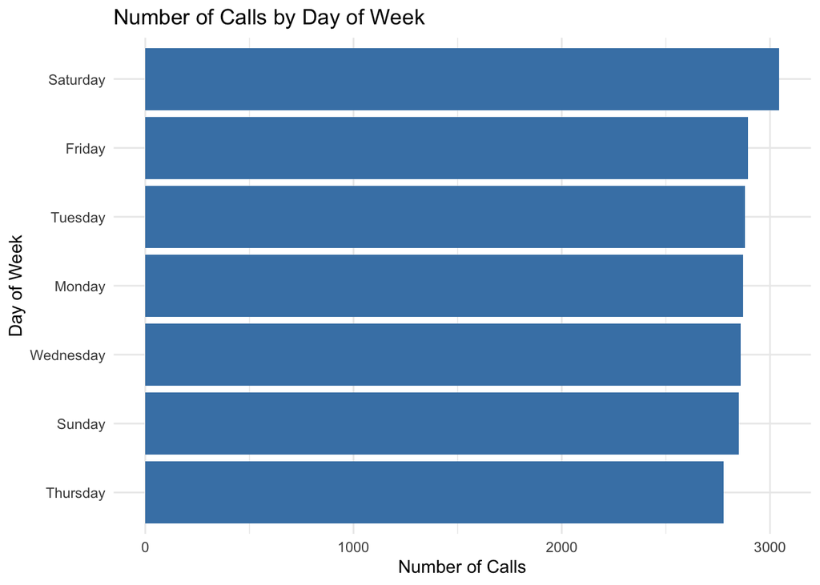

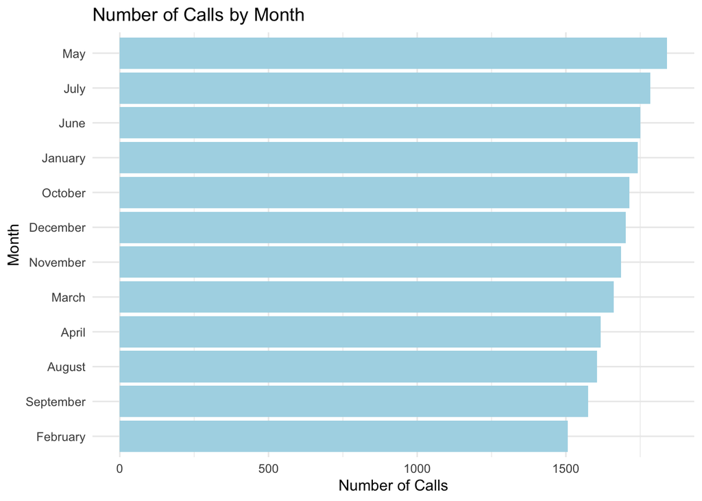

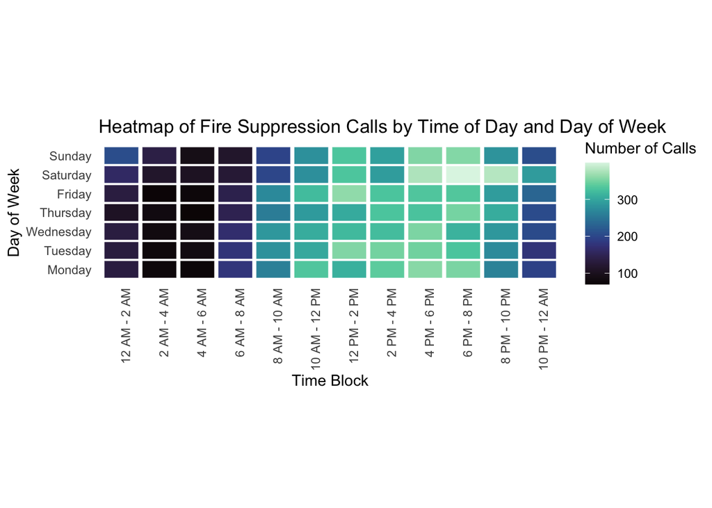

**Holidays v.s. Non-Holidays**

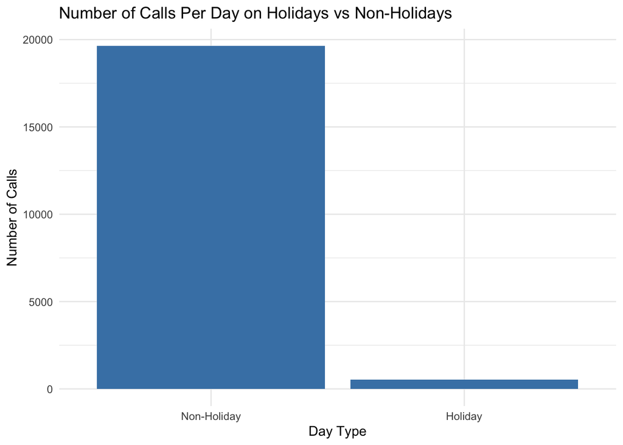

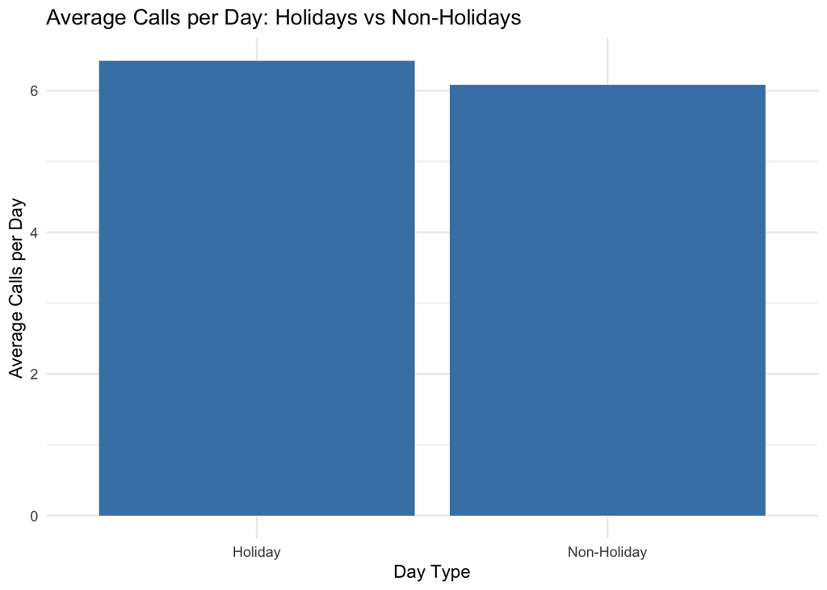

**Call Count by Time of Day**

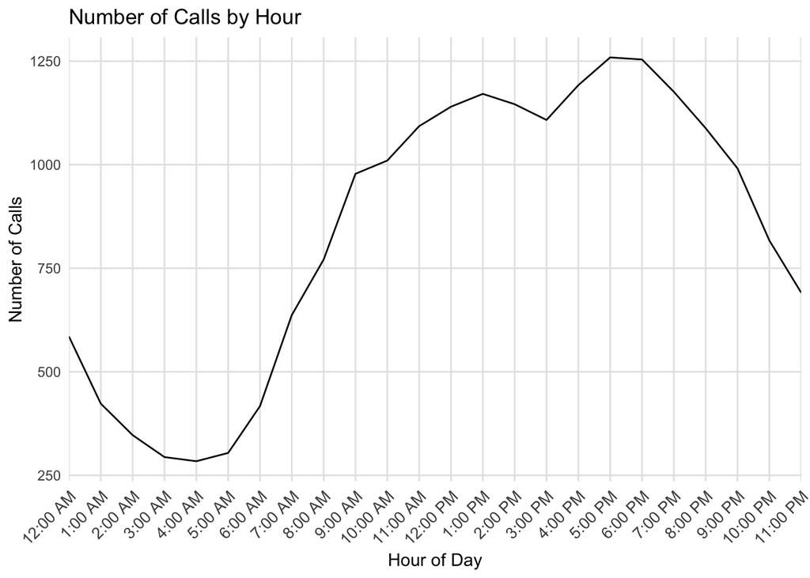

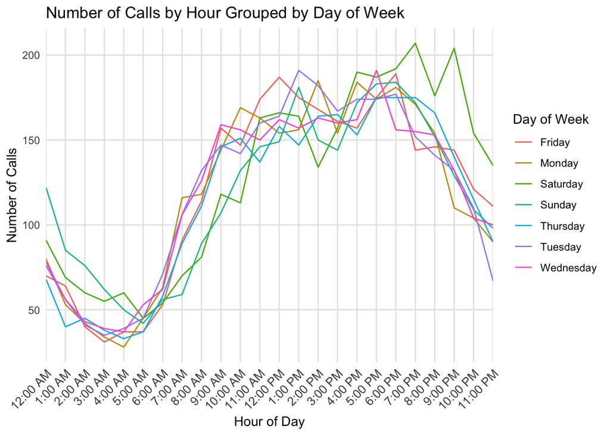

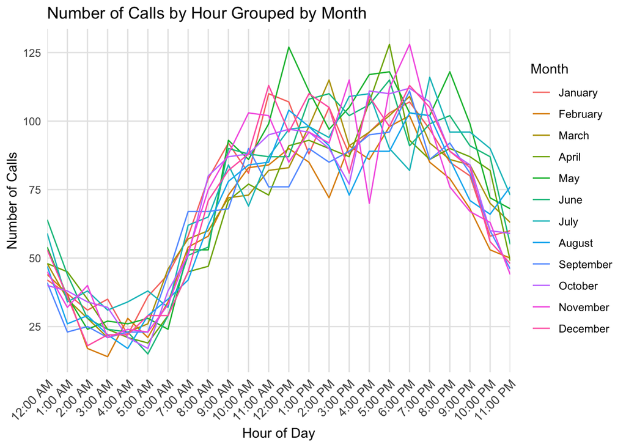

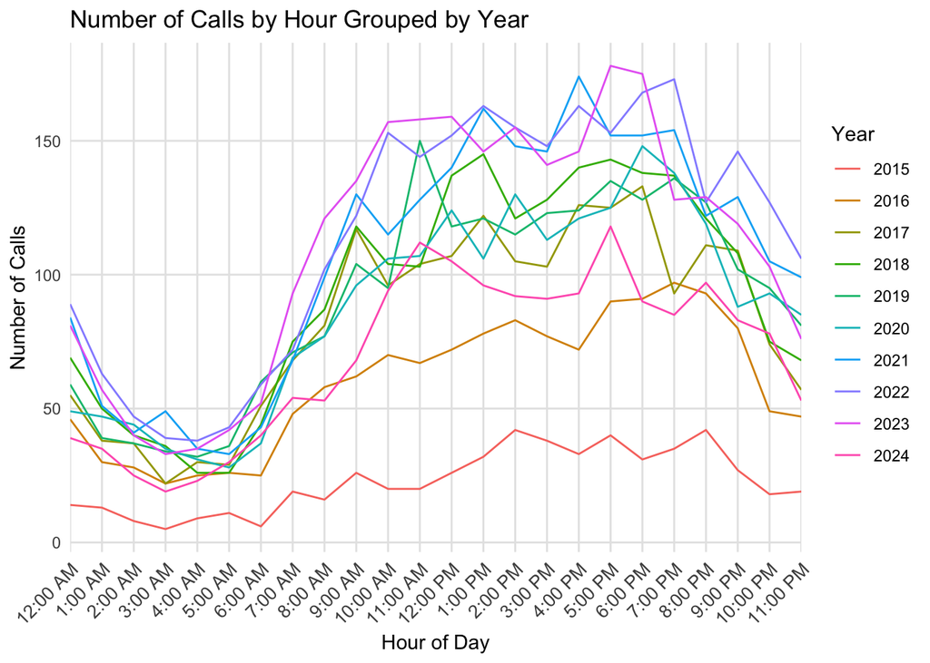

# Statistical Modeling

To predict and understand the number of fire suppression calls received throughout the day, we fit a generalized additive model. Unlike traditional models that assume a straight-line (linear) relationship between variables, GAMs allow for more flexible and curved relationships. This is particularly useful when the effect of time on call volumes isn’t a simple straight line but may vary in a more complex manner throughout the day.

### Model specification

The outcome of our model is the number of hourly calls. The predictor is a smoothed function of the time of day, binned by the hour. Call counts are whole numbers (i.e. you can’t have 2.5 calls). The Poisson distribution is ideal for modeling such count-based data, especially when the counts are relatively low and events occur independently.

### Running the GAM model

To prepare our data for regression, we must first clean and reshape the data. The cleaned data was also padded with zeros to indicate hours with no calls.

Before fitting the model, we split our data into training and testing sets. The seed is set for reproducibility.

Then, we fit the data on the training set.

Finally, we can use the model to predict the expected number of calls at any hour of day using “new” data, which is our testing set.

```r
predict = predict.gam(model, test_data, type = "response", se.fit = TRUE)
```

# Results

A plot of the expected number of calls is below, along with 95% confidence bands.

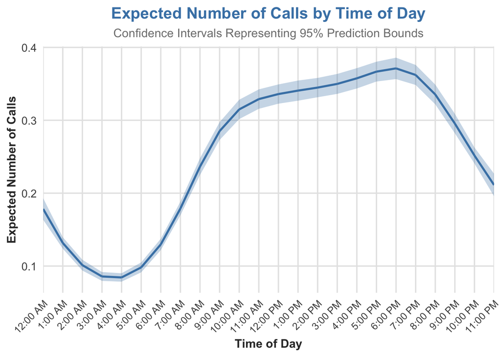

Interpretation:

- *Early Morning (12:00 AM - 6:00 AM)*: The expected number of calls is at its lowest during the early morning hours, particularly around 3:00 AM to 5:00 AM. This is likely because most people are inactive, and fewer incidents require fire suppression services during these hours.
- *Morning Increase (6:00 AM - 12:00 PM):* Starting from around 6:00 AM, the expected number of calls begins to rise significantly. This coincides with the start of the day when people are more active, and potential incidents that require fire suppression may increase.
- *Peak in Late Afternoon (3:00 PM - 6:00 PM):* The expected number of calls reaches its peak between 3:00 PM and 6:00 PM. This might be due to higher levels of activity during these hours, possibly related to both work and home-related incidents. The confidence bands are slightly wider here, suggesting more variability in the data during these hours.
- *Evening Decline (6:00 PM - 12:00 AM):* After the peak, the expected number of calls declines into the late evening. This makes sense as activities generally slow down, and fewer incidents requiring fire suppression occur.
- It is important to note a huge caveat of the analysis. Because our data contains a lot of zeros (i.e. there are hours of days with no calls, and we padded our data set with zero when there was no call), the expected number of calls will be lower than 1. Thus, this tool does not tell us how many calls to expect and when, but rather only detects the peak times of day for calls.

# Conclusion

These results may have practical implications to help with resource allocation, risk management, and operational planning during high v.s. low-demand periods.